# Amusing Algorithms 🤖

### [@maxhumber](https://twitter.com/maxhumber)

##### 🌉 PyBay 2018

[figure not shown]

github.com/maxhumber/amusing_algorithms

[figure not shown]

In ‘Amusing Algorithms’ we’ll cut through the math and try to understand the mechanics of a few interesting and useful algorithms. We’ll use **Jupyter** 📒 to expose data structures, intermediate steps, and simulations of various algorithms. And we’ll try to use algorithms to answer real life questions like how to **find love** ❤️ in a crowded bar, how to **buy the best scalpers tickets** 🎟 at a baseball game, and how to figure out when **you should leave your job** 🙅🏻‍♀️.

# - Optimal Stopping 🛑

# - Stable Marriage 💒

# - Simulated Annealing ⚔️

# Optimal Stopping 🛑

Imagine an administrator who wants to hire the best secretary out of n rankable applicants for a position. The applicants are interviewed one by one in random order. A decision about each particular applicant is to be made immediately after the interview. Once rejected, an applicant cannot be recalled. During the interview, the administrator can rank the applicant among all applicants interviewed so far, but is unaware of the quality of yet unseen applicants. The question is about the optimal strategy to maximize the probability of selecting the best applicant.

[figure not shown]

```python
low = 8
high = 24
N = 15
```

```python
import random
random.seed(14)

options = [random.randint(low, high) for i in range(N)]

print(options)
```

```
[11, 24, 15, 16, 16, 17, 10, 22, 17, 22, 20, 20, 11, 16, 15]
```

```python
for _ in range(5):
    options = [random.randint(low, high) for i in range(N)]
    print(options, '\n')
```

```
[18, 19, 16, 19, 24, 12, 13, 16, 13, 8, 10, 11, 18, 8, 10]

[16, 14, 20, 20, 22, 11, 11, 19, 13, 11, 23, 24, 14, 16, 22]

[14, 23, 17, 24, 16, 11, 11, 10, 16, 16, 11, 8, 13, 21, 11]

[24, 10, 21, 23, 13, 20, 22, 17, 23, 22, 21, 21, 11, 16, 23]

[20, 15, 22, 23, 10, 12, 23, 16, 22, 8, 20, 21, 8, 19, 19]
```

[figure not shown]

```python
random.seed(14)
options = [random.randint(low, high) for i in range(N)]
print(options)
```

```
[11, 24, 15, 16, 16, 17, 10, 22, 17, 22, 20, 20, 11, 16, 15]
```

# 🤖

1. Estimate how many possible options there are
2. Multiply that # by `1/e` or ~ 37%
3. Evaluate that # of options to establish a benchmark
4. Continue until you find an option that exceeds the benchmark

### 🐍

```python
import math
skip = int(len(options) / math.e)

bench = options[0]
for i, option in enumerate(options):
    if i < skip:
        if option <= bench:
            bench = option
    else:
        if option <= bench:
            break
```

```python
print(skip)
```

```
5
```

```python
print(f'Options: {options}')
print(f'Benchmark: {bench}')
print(f'Choice: {option} at position {i+1}/{len(options)}')
```

```
Options: [11, 24, 15, 16, 16, 17, 10, 22, 17, 22, 20, 20, 11, 16, 15]
Benchmark: 11
Choice: 10 at position 7/15
```

### Refactor 💄

```python
skip = int(len(options) / math.e)
bench = min(options[:skip])

for option in options[skip:]:
    if option <= bench:
        break
```

```python
def create_options(low=8, high=24, N=15):
    return [random.randint(low, high) for i in range(N)]
```

```python
print(create_options(8, 24, 15))
print('\n')
print(create_options(60, 100, 10))
```

```
[18, 19, 16, 19, 24, 12, 13, 16, 13, 8, 10, 11, 18, 8, 10]


[77, 73, 84, 85, 97, 88, 98, 66, 67, 97]
```

### Refactor 💄

```python
def buy(options, strategy='optimal'):
    if strategy == 'first':
        choice = options[0]
    if strategy == 'random':
        choice = random.choice(options)
    if strategy == 'optimal':
        skip = int(len(options) / math.e)
        bench = min(options[:skip])
        for option in options[skip:]:
            if option <= bench:
                break
        choice = option
    return 1 if choice == min(options) else 0
```

### Simulate ⏳

```python
outcomes = []
for i in range(1000):
    outcome = buy(create_options(low=8, high=24, N=15), 'optimal')
    outcomes.append(outcome)
sum(outcomes) / len(outcomes)
```

```
0.488
```

```python
outcomes = []
for i in range(1000):
    outcome = buy(create_options(8, 24, 15), 'first')
    outcomes.append(outcome)
sum(outcomes) / len(outcomes)
```

```
0.088
```

```python
outcomes = []
for i in range(1000):
    outcome = buy(create_options(8, 24, 15), 'random')
    outcomes.append(outcome)
sum(outcomes) / len(outcomes)
```

```
0.088
```

### 🧠

```
skip = 37%

for option in options[skip:]:
    if option <= bench:
        break
```

# Stable Marriage 💒

Given n men and n women, where each person has ranked all members of the opposite sex in order of preference, marry the men and women together such that there are no two people of opposite sex who would both rather have each other than their current partners. When there are no such pairs of people, the set of marriages is deemed stable.

### Friends 👫👫👫

[figure not shown]

### Data Structures 👷‍♂️

```python
class Person:
    def __init__(self, name, preferences):
        self.name = name
        self.partner = None
        self.preferences = preferences

    def __repr__(self):
        if self.partner:
            return f'{self.name} ⚭ {self.partner}'
        else:
            return f'{self.name} ⌀'
```

```python
ross = Person('Ross', ['Rachel', 'Phoebe', 'Monia'])
print('Name:', ross)
print('Partner:', ross.partner)
```

```
Name: Ross ⌀
Partner: None
```

```python
ross.partner = 'Rachel'
print(ross)
```

```
Ross ⚭ Rachel
```

### Functions 🍱

[figure not shown]

```python
import copy

class Alpha(Person):
    def __init__(self, name, preferences):
        super().__init__(name, preferences)
        self.not_asked = copy.deepcopy(preferences)

    def ask(self):
        return self.not_asked.pop(0)
```

```python
class Beta(Person):
    def __init__(self, name, preferences):
        super().__init__(name, preferences)

    def accept(self, suitor):
        return self.partner is None or (
            self.preferences.index(suitor) <
            self.preferences.index(self.partner)
        )
```

### Preferences 💏

```python
people = {
    "Men": {
        "Ross": ["Rachel", "Phoebe", "Monica"],
        "Chandler": ["Rachel", "Monica", "Phoebe"],
        "Joey": ["Phoebe", "Rachel", "Monica"]
    },
    "Women": {
        "Rachel": ["Joey", "Ross", "Chandler"],
        "Phoebe": ["Ross", "Chandler", "Joey"],
        "Monica": ["Joey", "Chandler", "Ross"]
    }
}
```

### Initialize 🌱

```python
def setup():
    global alphas
    global betas

    alphas = {}
    for key, value in people.get('Men').items():
        alphas[key] = Alpha(key, value)
    betas = {}
    for key, value in people.get('Women').items():
        betas[key] = Beta(key, value)
```

```python
setup()
print('A:', alphas)
print('B:', betas)
```

```
A: {'Ross': Ross ⌀, 'Chandler': Chandler ⌀, 'Joey': Joey ⌀}
B: {'Rachel': Rachel ⌀, 'Phoebe': Phoebe ⌀, 'Monica': Monica ⌀}
```

```python
unmatched = list(alphas.keys())
print(unmatched)
```

```
['Ross', 'Chandler', 'Joey']
```

# 🤖

1. Each unengaged man proposes to the woman he prefers most
2. Each woman says "maybe" to the suitor she most prefers and "no" to all other suitors
3. Continue while there are still unengaged men

```python
while unmatched:
    alpha = alphas[random.choice(unmatched)]
    beta = betas[alpha.ask()]
    if beta.accept(alpha.name):
        if beta.partner:
            ex = alphas[beta.partner]
            ex.partner = None
            unmatched.append(ex.name)
        unmatched.remove(alpha.name)
        alpha.partner, beta.partner = beta.name, alpha.name
```

```python
print(alphas)
print(betas)
```

```
{'Ross': Ross ⚭ Rachel, 'Chandler': Chandler ⚭ Monica, 'Joey': Joey ⚭ Phoebe}
{'Rachel': Rachel ⚭ Ross, 'Phoebe': Phoebe ⚭ Joey, 'Monica': Monica ⚭ Chandler}
```

[figure not shown]

# 🏎 ➡️ ➡️ ➡️ 🐢

```python
while unmatched:
    alpha = alphas[random.choice(unmatched)]
    beta = betas[alpha.ask()]
    if beta.accept(alpha.name):
        if beta.partner:
            ex = alphas[beta.partner]
            ex.partner = None
            unmatched.append(ex.name)
        unmatched.remove(alpha.name)
        alpha.partner, beta.partner = beta.name, alpha.name
```

```python
import time
random.seed(1993)
setup()
unmatched = list(alphas.keys())

while unmatched:
    alpha = alphas[random.choice(unmatched)]
    beta = betas[alpha.ask()]
    print(f'{alpha.name} asks {beta.name}')
    time.sleep(0.8)
    if beta.accept(alpha.name):
        print(f'{beta.name} accepts')
        if beta.partner:
            ex = alphas[beta.partner]
            print(f'{beta.name} dumps {ex.name}')
            ex.partner = None
            unmatched.append(ex.name)
        unmatched.remove(alpha.name)
        alpha.partner, beta.partner = beta.name, alpha.name
    else:
        print(f'{beta.name} rejects')
    time.sleep(0.8)
    print()
print('Everyone is matched! And things are stable 💪')
```

```
Chandler asks Rachel
Rachel accepts

Joey asks Phoebe
Phoebe accepts

Ross asks Rachel
Rachel accepts
Rachel dumps Chandler

Chandler asks Monica
Monica accepts

Everyone is matched! And things are stable 💪
```

```python
def print_pairings(people):
    for p in people.values():
        if p.partner:
            print(f'{p.name} is paired with {p.partner} ({p.preferences.index(p.partner) + 1})')
        else:
            print(f'{p.name} is not paired')
```

```python
print_pairings(alphas)
print('\n')
print_pairings(betas)
```

```
Ross is paired with Rachel (1)
Chandler is paired with Monica (2)
Joey is paired with Phoebe (1)


Rachel is paired with Ross (2)
Phoebe is paired with Joey (3)
Monica is paired with Chandler (2)
```

[figure not shown]

```python
alphas = {}
for key, value in people.get('Women').items():
    alphas[key] = Alpha(key, value)
betas = {}
for key, value in people.get('Men').items():
    betas[key] = Beta(key, value)

unmatched = list(alphas.keys())
```

```python
while unmatched:
    alpha = alphas[random.choice(unmatched)]
    beta = betas[alpha.ask()]
    if beta.accept(alpha.name):
        if beta.partner:
            ex = alphas[beta.partner]
            ex.partner = None
            unmatched.append(ex.name)
        unmatched.remove(alpha.name)
        alpha.partner, beta.partner = beta.name, alpha.name
```

```python
print_pairings(alphas)
print('\n')
print_pairings(betas)
```

```
Rachel is paired with Joey (1)
Phoebe is paired with Ross (1)
Monica is paired with Chandler (2)


Ross is paired with Phoebe (2)
Chandler is paired with Monica (2)
Joey is paired with Rachel (2)
```

[figure not shown]

### 🧠

> "Pearls don’t lie on the seashore. If you want one, you must dive for it."

— Chinese proverb

> "Opportunity dances with those on the dance floor."

— Anonymous

# Simulated Annealing ⚔️

[figure not shown]

Imagine you are situated at the bottom of a mountain, and you want to make your way up by foot to the highest point in the valley. But you cannot see beyond your feet, so your algorithm is simply to keep heading uphill. You do that, and eventually, half way up the mountain, you end up at the top of a small peak, from which all paths lead down. As far as you can nearsightedly tell, you’ve reached the highest point. But it’s a local maximum, not truly the top of the mountain, and you’re not where you need to be.

What would be a better algorithm for someone with purely local vision? Simulated annealing, inspired by sword makers.

### Setup 💼

```python
def clamp(x, low, high):
    return max(min(x, high), low)
```

```python
def linspace(low, high, steps):
    return [low + x * (high - low)/steps for x in range(steps)]
```

```python
import math

def f(x):
    x = clamp(x, 0, 10)
    return x * math.sin(x) + x * math.cos(2 * x) + 10
```

```python
xs = linspace(0, 10, 100)
ys = [f(x) for x in xs]
```

```python
from matplotlib import pyplot as plt
%matplotlib inline

plt.figure(figsize=(10, 6))
plt.plot(xs, ys)
```

[output not shown]

```python
x = 4
fx = f(x)
print(fx)
```

```
6.390789883533833
```

```python
x = 5
fx = f(x)
print(fx)
```

```
1.0100209813020449
```

```python
import random

random.seed(1993)
x2 = x + random.choice([-1, 1]) * 0.001
fx2 = f(x2)
print(fx)
print(fx2)
```

```
1.0100209813020449
1.015093665555547
```

```python
if fx2 > fx:
    print('fx2 is better')
    x, fx = x2, fx
else:
    print('fx2 is worse')
```

```
fx2 is better
```

# 💄

```python
def hill_climb(x, f, steps=1000):
    fx = f(x)
    for i in range(steps):
        x2 = x + random.choice([-1, 1]) * 0.01
        fx2 = f(x2)
        if fx2 > fx:
            x, fx = x2, fx2
    return x, fx
```

```python
hill_climb(4, f)
```

```
(2.9800000000000217, 13.30517440563907)
```

```python
hill_climb(5, f)
```

```
(6.579999999999966, 17.378756955031456)
```

```python
plt.figure(figsize=(10, 6))
plt.plot(xs, ys)
# plt.scatter(4, f(4), c='r')
# plt.scatter(5, f(5), c='k')
```

[figure not shown]

### Pseudocode 📄

```
Let s = s0
For k = 0 through kmax (exclusive):
T ← temperature(k ∕ kmax)
Pick a random neighbour, snew ← neighbour(s)
If P(E(s), E(snew), T) ≥ random(0, 1):
s ← snew
Output: the final state s
```

```python
def prob(old, new, temperature):
    # if trying to minimize: math.exp(-(new - old) / temperature)
    return math.exp(-(old - new) / temperature)
```

```python
old = 10
new = 9
```

```python
print(prob(old, new, temperature=10))
print(prob(old, new, temperature=1))
```

```
0.9048374180359595
0.36787944117144233
```

```python
temperature = 1000
a = 0.99
for _ in range(1000):
    print(temperature)
    temperature *= a
```

```
1000
990.0
980.1
970.299
960.59601
950.9900498999999
941.480149401
932.0653479069899
922.74469442792
913.5172474836407
904.3820750088043
895.3382542587163
886.3848717161292
877.5210229989679
868.7458127689781
860.0583546412884
851.4577710948755
842.9431933839268
834.5137614500875
826.1686238355866
817.9069375972307
809.7278682212584
801.6305895390458
793.6142836436553
785.6781408072187
777.8213593991466
770.0431458051551
762.3427143471035
754.7192872036325
747.1720943315961
739.7003733882801
732.3033696543973
724.9803359578533
717.7305325982747
710.553227272292
703.4476949995691
696.4132180495734
689.4490858690776
682.5545950103868
675.7290490602829
```

[output cut: 945 more lines]

```
0.05019571890405464
0.04969376171501409
0.04919682409786395
0.04870485585688531
0.048217807298316456
0.04773562922533329
0.04725827293307996
0.046785690203749154
0.046317833301711665
0.04585465496869455
0.045396108419007604
0.04494214733481753
0.04449272586146935
0.044047798602854654
0.04360732061682611
```

```python
current = 4
temperature = 1000
alpha = 0.90

for _ in range(100):
    new = random.uniform(0, 10)
    if prob(f(current), f(new), temperature) >= random.random():
        current = new
    print(current)
    temperature *= alpha
```

```
1.7700785521081652
5.633907710123496
9.298549394099815
5.313902128862194
6.934772239279181
2.710174387053108
3.463236722380836
1.8658695783861945
0.7481039156276703
7.912576103000829
6.21373246211167
5.881418313013704
1.6567079967507392
6.031951626352329
2.9687915521138097
0.18168560655076882
0.25396136372275
1.5050533855073012
0.6250659990271412
8.322260086545093
7.577101925745061
4.427300722589104
2.5261051713654448
6.894017343996765
8.415848317721514
2.992930716881194
6.767067712704805
8.964399031932889
2.88075971668305
5.880349525599012
5.151464089938686
6.155565574368559
5.343506211373717
3.678544357713751
2.0244087192422286
5.610283560505596
7.055390772875948
7.055390772875948
5.6461730318332
3.2665201578262626
```

[output cut: 45 more lines]

```
9.328537297301256
9.328537297301256
9.328537297301256
9.328537297301256
9.328537297301256
9.328537297301256
9.328537297301256
9.328537297301256
9.328537297301256
9.328537297301256
9.328537297301256
9.328537297301256
9.328537297301256
9.328537297301256
9.328537297301256
```

```python
plt.figure(figsize=(10, 6))
plt.plot(xs, ys)
```

[output not shown]

```python
import pathlib
import re
import random
import imageio
```

```python
random.seed(1993)
current = 4
temperature = 1000
alpha = 0.90

x = [current]
y = [f(current)]
t = [temperature]

for _ in range(99):
    new = random.uniform(0, 10)
    if prob(f(current), f(new), temperature) >= random.random():
        current = new
    x.append(current)
    y.append(f(current))
    t.append(temperature)
    temperature *= alpha
```

```python
print(len(x))
print(len(y))
print(len(t))
```

```
100
100
100
```

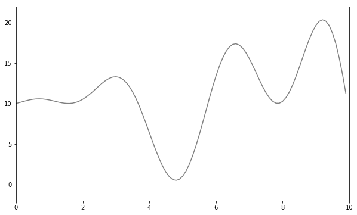

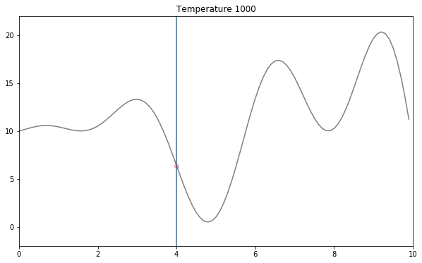

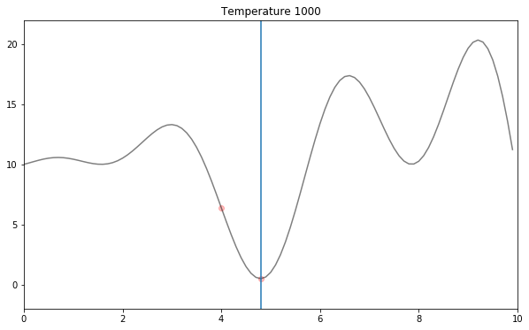

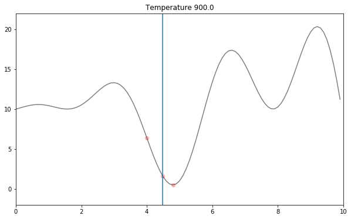

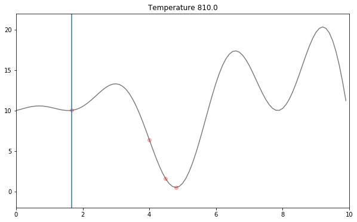

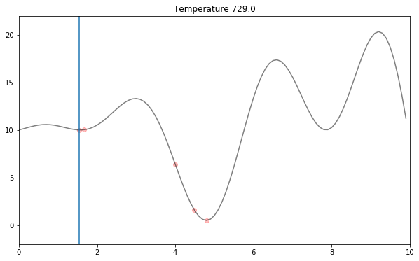

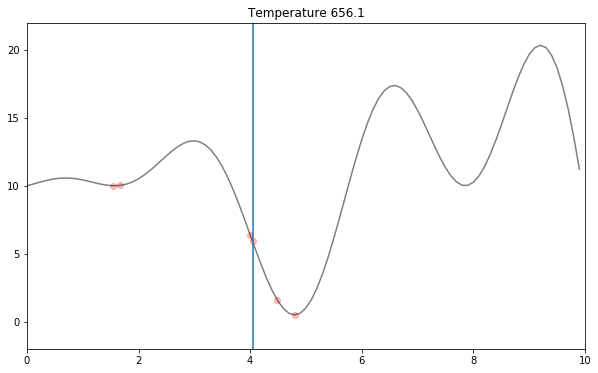

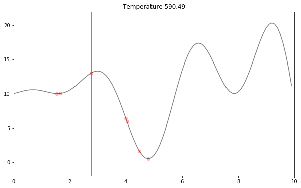

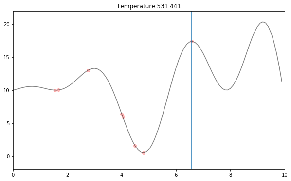

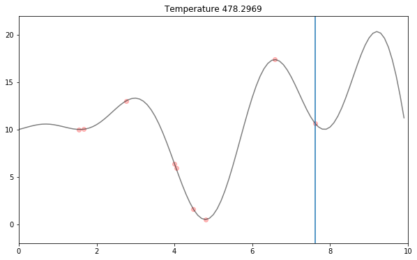

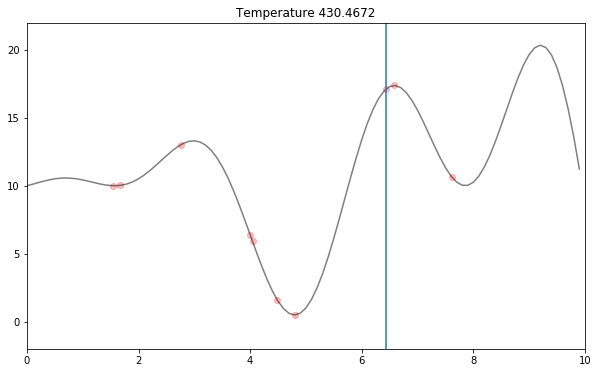

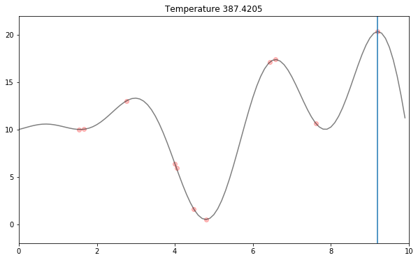

[88 more figures not shown]

```python
# create temp path for deletion later
p = pathlib.Path('temp/')
p.mkdir(parents=True, exist_ok=True)

# build all of the individual graphs
for i in range(len(x)):
    plt.figure(figsize=(10, 6))
    plt.plot(xs, ys, c='k', alpha=0.5)
    plt.scatter(x[:i], y[:i], c='r', alpha=0.25)
    try:
        plt.axvline(x[:i][-1])
        plt.title(f'Temperature {round(t[:i][-1], 4)}')
    except IndexError:
        pass
    plt.ylim(-2, 22)
    plt.xlim(0, 10)
    plt.savefig(p / f'{i}.png')
```

```python
filenames = [str(x) for x in p.glob('*.png')]
filenames.sort(key=lambda x: int(re.sub('\D', '', x)))

# build gif and clean up pictures
images = []
for filename in filenames:
    images.append(imageio.imread(filename))
imageio.mimsave('images/sim_anneal.gif', images, duration=0.1)
```

```python
[x.unlink() for x in p.iterdir()]
p.rmdir()
```

[figure not shown]

# 🧠

> Simulated annealing employs judicious volatility in the hope that it will be beneficial. In an impossibly complex world, we should perhaps shun temporary stability and instead be willing to tolerate a bit of volatility in order to find a greater stability thereafter.

[figure not shown]

# Shameless Plug

[figure not shown]

# Speakerdeck: /maxhumber

# LinkedIn: /maxhumber

# Twitter: [@maxhumber](https://twitter.com/maxhumber)